# Practice Activity 6.1: Polynomial Regression

Author

Samuel Lonac

# Palmer Penguins Modeling

Import the Palmer Penguins dataset and print out the first few rows.

Suppose we want to predict `bill_depth_mm` using the other variables in the dataset.

Which variables would we need to **dummify**?

```python
pip install palmerpenguins
```

```python
from palmerpenguins import load_penguins
from sklearn.pipeline import Pipeline
from sklearn.linear_model import LinearRegression
from sklearn.model_selection import train_test_split
from sklearn.compose import ColumnTransformer
from sklearn.preprocessing import PolynomialFeatures
from sklearn.preprocessing import OneHotEncoder
import numpy as np
```

Multiple Regression Example

```python
penguins = load_penguins()
penguins = penguins.dropna()
X = penguins.drop('bill_length_mm', axis = 1)
y = penguins['bill_length_mm']

X_train, X_test, y_train, y_test = train_test_split(X, y)
```

```python
X_train
```

|  | species | island | bill_depth_mm | flipper_length_mm | body_mass_g | sex | year |
| --- | --- | --- | --- | --- | --- | --- | --- |
| 21 | Adelie | Biscoe | 18.7 | 180.0 | 3600.0 | male | 2007 |
| 247 | Gentoo | Biscoe | 15.7 | 226.0 | 5200.0 | male | 2009 |
| 312 | Chinstrap | Dream | 18.3 | 195.0 | 3850.0 | female | 2008 |
| 114 | Adelie | Biscoe | 20.7 | 191.0 | 3900.0 | female | 2009 |
| 82 | Adelie | Torgersen | 18.8 | 187.0 | 3800.0 | female | 2008 |
| ... | ... | ... | ... | ... | ... | ... | ... |
| 34 | Adelie | Dream | 17.0 | 195.0 | 3325.0 | female | 2007 |
| 252 | Gentoo | Biscoe | 15.0 | 219.0 | 4850.0 | female | 2009 |
| 100 | Adelie | Biscoe | 17.9 | 192.0 | 3725.0 | female | 2009 |
| 278 | Chinstrap | Dream | 19.2 | 193.0 | 3650.0 | male | 2007 |
| 75 | Adelie | Torgersen | 18.5 | 195.0 | 4250.0 | male | 2008 |

249 rows × 7 columns

```python
## Preprocessing: One-Hot-Encode
## Model Spec: Linear Regression

lr = LinearRegression()
enc = OneHotEncoder()


ct = ColumnTransformer(
    [('dummify_s', enc, ['species']),
     ('dummify_i', enc, ['island']),
     ('dummify_sex', enc, ['sex'])],
)

my_pipeline = Pipeline(
  [('dummify_everything' , ct), ('ols', lr)]
)
```

```python
ct
```

```
ColumnTransformer(transformers=[('dummify_s', OneHotEncoder(), ['species']),
                                ('dummify_i', OneHotEncoder(), ['island']),
                                ('dummify_sex', OneHotEncoder(), ['sex'])])
```

```python
my_pipeline
```

```
Pipeline(steps=[('dummify_everything',
                 ColumnTransformer(transformers=[('dummify_s', OneHotEncoder(),
                                                  ['species']),
                                                 ('dummify_i', OneHotEncoder(),
                                                  ['island']),
                                                 ('dummify_sex',
                                                  OneHotEncoder(), ['sex'])])),
                ('ols', LinearRegression())])
```

```python
fitted_pipeline = my_pipeline.fit(X_train, y_train)
```

```python
fitted_pipeline
```

```
Pipeline(steps=[('dummify_everything',
                 ColumnTransformer(transformers=[('dummify_s', OneHotEncoder(),
                                                  ['species']),
                                                 ('dummify_i', OneHotEncoder(),
                                                  ['island']),
                                                 ('dummify_sex',
                                                  OneHotEncoder(), ['sex'])])),
                ('ols', LinearRegression())])
```

```python
y_preds = fitted_pipeline.predict(X_test)
```

```python
y_preds
```

```
array([37.5   , 45.4375, 40.875 , 36.9375, 49.125 , 50.    , 40.875 ,
       50.    , 41.125 , 37.1875, 36.9375, 37.5   , 37.1875, 36.9375,
       49.125 , 49.125 , 41.125 , 40.625 , 50.    , 45.4375, 49.125 ,
       37.5   , 46.375 , 50.    , 46.375 , 49.125 , 49.125 , 49.125 ,
       41.125 , 49.125 , 50.    , 36.9375, 45.4375, 45.4375, 50.    ,
       45.4375, 45.4375, 46.375 , 37.1875, 49.125 , 40.625 , 37.1875,
       46.375 , 40.625 , 50.    , 50.    , 37.5   , 49.125 , 45.4375,
       41.125 , 40.875 , 50.    , 45.4375, 46.375 , 37.5   , 40.875 ,
       40.875 , 49.125 , 49.125 , 45.4375, 49.125 , 46.375 , 36.9375,
       49.125 , 40.875 , 40.625 , 40.875 , 45.4375, 49.125 , 45.4375,
       37.1875, 37.1875, 45.4375, 40.625 , 40.625 , 37.5   , 45.4375,
       36.9375, 40.875 , 46.375 , 49.125 , 50.    , 37.1875, 46.375 ])
```

Let’s use `bill_length_mm` to predict `bill_depth_mm`. Prepare your data and fit the following models on the entire dataset:

- Simple linear regression (e.g. straight-line) model
- Quadratic (degree 2 polynomial) model
- Cubic (degree 3 polynomial) model
- Degree 10 polynomial model

Make predictions for each model and plot your fitted models on the scatterplot.

```python
## Preprocessing:
## Model Spec: Simple Linear Regression

X = penguins[['bill_length_mm']]
y = penguins['bill_depth_mm']

X_train, X_test, y_train, y_test = train_test_split(X, y)

lr = LinearRegression()

simple_pipeline = Pipeline(
  [('ols', lr)]
)
```

```python
fitted_simple_pipeline = simple_pipeline.fit(X_train, y_train)
y_preds_simple = fitted_simple_pipeline.predict(X_test)
```

```python
y_preds_simple
```

```
array([17.55907135, 17.45398302, 17.41645147, 16.42561863, 16.49317541,
       17.62662814, 17.28884421, 17.85932373, 17.53655243, 17.08617386,
       17.7542354 , 17.8368048 , 17.06365493, 17.66415969, 17.65665338,
       17.52904612, 16.78592148, 16.98108553, 16.65080791, 17.09368017,
       16.77841517, 16.70335208, 16.8009341 , 17.78426064, 17.03362969,
       17.58909659, 17.53655243, 17.19126219, 17.58159028, 17.37141362,
       17.60410921, 17.06365493, 16.78592148, 16.65080791, 17.31136314,
       17.60410921, 17.82929849, 17.70169123, 17.34889469, 17.41645147,
       17.55907135, 17.41645147, 17.79927326, 16.93604767, 16.86098458,
       17.06365493, 16.92854136, 16.60577005, 17.70169123, 17.56657766,
       17.6791723 , 17.52153981, 16.82345303, 17.30385683, 17.25881898,
       17.00360446, 16.75589624, 16.9585666 , 17.10869279, 16.99609815,
       17.78426064, 16.99609815, 17.29635052, 16.86849089, 17.01861707,
       17.60410921, 16.74838993, 17.34889469, 17.01111076, 16.54571958,
       16.8835035 , 17.58909659, 17.04864231, 17.52153981, 17.64164076,
       16.81594672, 16.8009341 , 17.7542354 , 17.80677956, 17.13121172,
       16.66582053, 17.74672909, 17.45398302, 17.49151457])
```

```python
## Model Spec: Quadratic

lr = LinearRegression()
poly = PolynomialFeatures(2)


ct = ColumnTransformer(
    [('square', poly, ['bill_length_mm'])]
)

quad_pipeline = Pipeline(
  [('make_polynomial' , ct), ('ols', lr)]
)
```

```python
fitted_quad_pipeline = quad_pipeline.fit(X_train, y_train)
y_preds_quad = fitted_quad_pipeline.predict(X_test)
```

```python
## Preprocessing: One-Hot-Encode
## Model Spec: Cubic

lr = LinearRegression()
poly = PolynomialFeatures(3)


ct = ColumnTransformer(
    [('cube', poly, ['bill_length_mm'])]
)

cube_pipeline = Pipeline(
  [('make_polynomial' , ct), ('ols', lr)]
)
```

```python
fitted_cube_pipeline = cube_pipeline.fit(X_train, y_train)
y_preds_cube = fitted_cube_pipeline.predict(X_test)
```

```python
## Preprocessing: One-Hot-Encode
## Model Spec: Degree 10

lr = LinearRegression()
poly = PolynomialFeatures(10)


ct = ColumnTransformer(
    [('deg10', poly, ['bill_length_mm'])]
)

deg10_pipeline = Pipeline(
  [('make_polynomial' , ct), ('ols', lr)]
)
```

```python
fitted_deg10_pipeline = deg10_pipeline.fit(X_train, y_train)
y_preds_deg10 = fitted_deg10_pipeline.predict(X_test)
```

```python
from plotnine import ggplot, aes, geom_point, geom_line
```

```python
final_df = X_test
final_df['bill_depth_mm'] = y_test
final_df['Linear Predictions'] = y_preds_simple
final_df['Quadratic Predictions'] = y_preds_quad
final_df['Cubic Predictions'] = y_preds_cube
final_df['Degree 10 Predictions'] = y_preds_deg10
```

```python
final_df
```

|  | bill_length_mm | bill_depth_mm | Linear Predictions | Quadratic Predictions | Cubic Predictions | Degree 10 Predictions |
| --- | --- | --- | --- | --- | --- | --- |
| 7 | 39.2 | 19.6 | 17.559071 | 17.481655 | 17.780107 | 18.514753 |
| 26 | 40.6 | 18.6 | 17.453983 | 17.216650 | 17.535454 | 18.221133 |
| 12 | 41.1 | 17.6 | 17.416451 | 17.134673 | 17.442976 | 18.035049 |
| 215 | 54.3 | 15.7 | 16.425619 | 17.382049 | 17.594364 | 19.276125 |
| 259 | 53.4 | 15.8 | 16.493175 | 17.217561 | 17.240385 | 19.145170 |
| ... | ... | ... | ... | ... | ... | ... |
| 200 | 44.9 | 13.3 | 17.131212 | 16.729551 | 16.773946 | 16.069613 |
| 251 | 51.1 | 16.5 | 16.665821 | 16.895350 | 16.660317 | 17.635835 |
| 4 | 36.7 | 19.3 | 17.746729 | 18.084899 | 18.108630 | 18.173416 |
| 57 | 40.6 | 18.8 | 17.453983 | 17.216650 | 17.535454 | 18.221133 |
| 51 | 40.1 | 18.9 | 17.491515 | 17.305294 | 17.625834 | 18.366595 |

84 rows × 6 columns

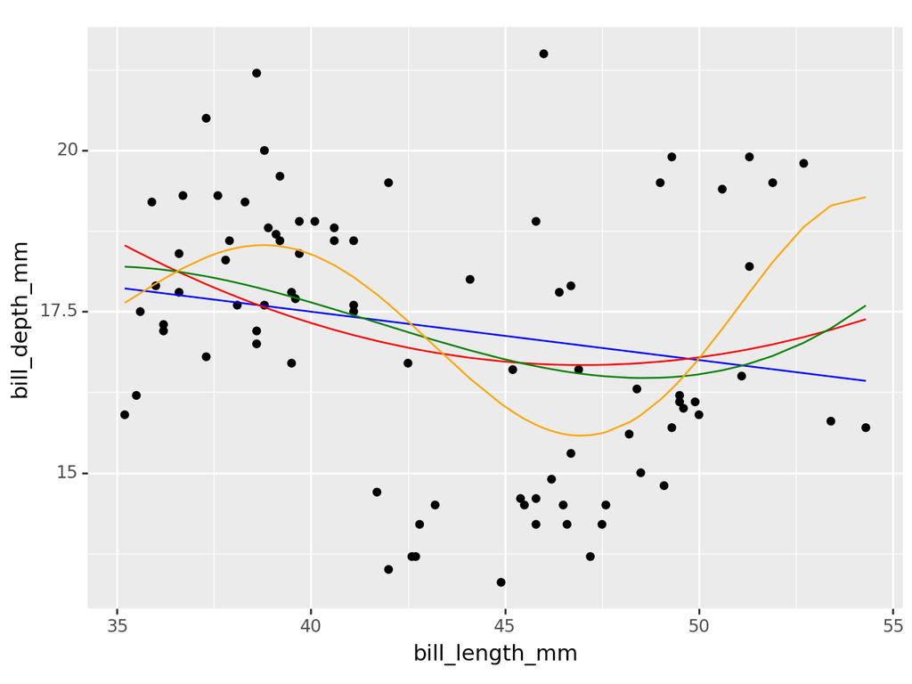

```
<Figure Size: (640 x 480)>
```

```python
(ggplot(final_df,
  aes(
      x = "bill_length_mm",
      y = "bill_depth_mm"
))
+ geom_point()
+ geom_line(aes(y = "Linear Predictions"), color = "blue")
+ geom_line(aes(y = "Quadratic Predictions"), color = "red")
+ geom_line(aes(y = "Cubic Predictions"), color = "green")
+ geom_line(aes(y = "Degree 10 Predictions"), color = "orange")
)
```

- Are any of the models above underfitting the data? If so, which ones and how can you tell?
- Are any of thhe models above overfitting the data? If so, which ones and how can you tell?
- Which of the above models do you think fits the data best and why?

The simple model is underfitting the data, becauase the straight line is not capturing some of the nuances or patterns of the data points.

The Degree 10 model is overfitting the data because the curves are dramatic and seem to be too fit on this specific set of data.

I believe that the quadratic model best fits the data because it captures the up and down groupings of the data but does not have a dramatic uptick at the end.